# UCLA Statistical Consulting Example

This vignette replicates the [ordinal logistic regression example](https://stats.idre.ucla.edu/r/dae/ordinal-logistic-regression/) done by the [UCLA Statistical Consulting Group](https://stats.idre.ucla.edu/). It demonstrates how to use the `pomcheckr` package to check if the proportional odds assumption holds.

## Load packages and data

```r
library(pomcheckr)
library(ggplot2)
data(ologit)
```

## Description of Data

```r
head(ologit)
```

```
#> # A tibble: 6 x 4
#>   apply           pared public   gpa
#>   <fct>           <fct> <fct>  <dbl>
#> 1 very likely     0     0       3.26
#> 2 somewhat likely 1     0       3.21
#> 3 unlikely        1     1       3.94
#> 4 somewhat likely 0     0       2.81
#> 5 somewhat likely 0     0       2.53
#> 6 unlikely        0     1       2.59
```

`ologit` is a synthetic data set consisting of the following:

- apply - indicates how likely a student is to apply to graduate school
- pared - 1 if at least one parent has a graduate degree, 0 otherwise
- public - 1 if the undergraduate institution if public, 0 otherwise
- gpa - the student’s grade point average

## Descriptive Statistics

Some of the descriptive statistics from the example are repeated below.

```r
## one at a time, table apply, pared, and public
lapply(ologit[, c("apply", "pared", "public")], table)
```

```
#> $apply
#>
#>        unlikely somewhat likely     very likely
#>             220             140              40
#>
#> $pared
#>
#>   0   1
#> 337  63
#>
#> $public
#>
#>   0   1
#> 343  57
```

```r
## three way cross tabs (xtabs) and flatten the table
ftable(xtabs(~ public + apply + pared, data = ologit))
```

```
#>                        pared   0   1
#> public apply
#> 0      unlikely              175  14
#>        somewhat likely        98  26
#>        very likely            20  10
#> 1      unlikely               25   6
#>        somewhat likely        12   4
#>        very likely             7   3
```

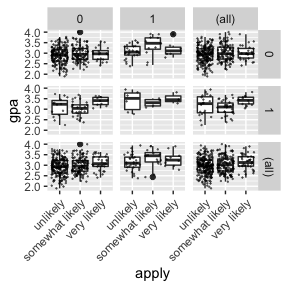

```r
ggplot(ologit, aes(x = apply, y = gpa)) +
  geom_boxplot() +
  geom_jitter(size=0.1, alpha = .5) +
  facet_grid(pared ~ public, margins = TRUE) +
  theme(axis.text.x = element_text(angle = 45, hjust = 1, vjust = 1))
```

## Analysis

The [source page](https://stats.idre.ucla.edu/r/dae/ordinal-logistic-regression/) describes various analysis methods that one might consider and what the limitations are with respect to this data set. Since the outcome `apply` is an ordered, categorical variable an ordered logistic (aka cumulative logit) model is an appropriate choice.

### Proportional Odds Assumption

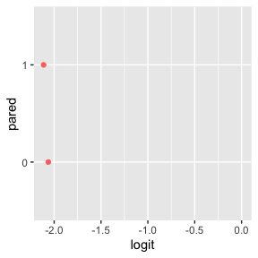

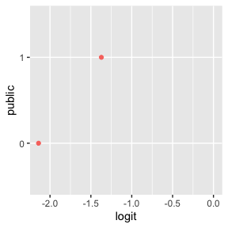

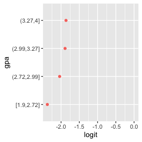

```r
plot(pomcheck(apply ~ pared + public + gpa, data=ologit))
```

The basic idea is a series of binary logistic regressions without the parallel slopes assumption are run on the response against the predictors. Then we check for equality of the slope coefficients across levels of the predictor (or cutpoints if the predictor is continuous). See the [source page](https://stats.idre.ucla.edu/r/dae/ordinal-logistic-regression/) for further details.

In the above plots, the slope coefficients are roughly equal for both `pared` and `gpa`. However, the plot for `public` suggests the parallel slopes assumption is *not* satisfied for that predictor.